#Download and then view it in your Browser.

# Google Capstone Cyclistic Case Study

Talha Saleem

2023-03-17

### Downloading and Storing Data

- Data can be downloaded using following link. https://divvy-tripdata.s3.amazonaws.com/index.html
- Data is organized in monthly datasets, so we need to download data from last 12 months. Note: Data is from March 2022 to February 2023
- Data is unbiased and credible and it does ROCCC. Reliable Yes Original Yes Comprehensive Yes Current Yes Cited Yes
- Data in all datasets is organized in same format (all datasets contain same 13 columns with same names)

### Loading Packages

```r
library(tidyverse)
library(here)
library(skimr)
library(janitor)
```

### Loading Datasets

Note: We have montly datasets from cyclistic company, so first we need to load them and then merge them.

```r
march_2022 <- read_csv("D:/da/google/project/case study 1/202203-divvy-tripdata.csv")
april_2022 <- read_csv("D:/da/google/project/case study 1/202204-divvy-tripdata.csv")
may_2022 <- read_csv("D:/da/google/project/case study 1/202205-divvy-tripdata.csv")
june_2022 <- read_csv("D:/da/google/project/case study 1/202206-divvy-tripdata.csv")
july_2022 <- read_csv("D:/da/google/project/case study 1/202207-divvy-tripdata.csv")
August_2022 <- read_csv("D:/da/google/project/case study 1/202208-divvy-tripdata.csv")
sep_2022 <- read_csv("D:/da/google/project/case study 1/202209-divvy-publictripdata.csv")
oct_2022 <- read_csv("D:/da/google/project/case study 1/202210-divvy-tripdata.csv")
nov_2022 <- read_csv("D:/da/google/project/case study 1/202211-divvy-tripdata.csv")
dec_2022 <- read_csv("D:/da/google/project/case study 1/202212-divvy-tripdata.csv")
jan_2023 <- read_csv("D:/da/google/project/case study 1/202301-divvy-tripdata.csv")
feb_2023 <- read_csv("D:/da/google/project/case study 1/202302-divvy-tripdata.csv")
```

### Merging Datasets

Note: We will use rbind function for merging datasets.

```r
cyclist_merged <- rbind(march_2022,april_2022,may_2022,june_2022,july_2022,August_2022,sep_2022,oct_2022,nov_2022,dec_2022,jan_2023,feb_2023)
```

### Viewing Data

- Structure of Dataset

```r
str(cyclist_merged)
```

```
## spc_tbl_ [5,829,084 × 13] (S3: spec_tbl_df/tbl_df/tbl/data.frame)
##  $ ride_id           : chr [1:5829084] "47EC0A7F82E65D52" "8494861979B0F477" "EFE527AF80B66109" "9F446FD9DEE3F389" ...
##  $ rideable_type     : chr [1:5829084] "classic_bike" "electric_bike" "classic_bike" "classic_bike" ...
##  $ started_at        : POSIXct[1:5829084], format: "2022-03-21 13:45:01" "2022-03-16 09:37:16" ...
##  $ ended_at          : POSIXct[1:5829084], format: "2022-03-21 13:51:18" "2022-03-16 09:43:34" ...
##  $ start_station_name: chr [1:5829084] "Wabash Ave & Wacker Pl" "Michigan Ave & Oak St" "Broadway & Berwyn Ave" "Wabash Ave & Wacker Pl" ...
##  $ start_station_id  : chr [1:5829084] "TA1307000131" "13042" "13109" "TA1307000131" ...
##  $ end_station_name  : chr [1:5829084] "Kingsbury St & Kinzie St" "Orleans St & Chestnut St (NEXT Apts)" "Broadway & Ridge Ave" "Franklin St & Jackson Blvd" ...
##  $ end_station_id    : chr [1:5829084] "KA1503000043" "620" "15578" "TA1305000025" ...
##  $ start_lat         : num [1:5829084] 41.9 41.9 42 41.9 41.9 ...
##  $ start_lng         : num [1:5829084] -87.6 -87.6 -87.7 -87.6 -87.6 ...
##  $ end_lat           : num [1:5829084] 41.9 41.9 42 41.9 41.9 ...
##  $ end_lng           : num [1:5829084] -87.6 -87.6 -87.7 -87.6 -87.7 ...
##  $ member_casual     : chr [1:5829084] "member" "member" "member" "member" ...
##  - attr(*, "spec")=
##   .. cols(
##   ..   ride_id = col_character(),
##   ..   rideable_type = col_character(),
##   ..   started_at = col_datetime(format = ""),
##   ..   ended_at = col_datetime(format = ""),
##   ..   start_station_name = col_character(),
##   ..   start_station_id = col_character(),
##   ..   end_station_name = col_character(),
##   ..   end_station_id = col_character(),
##   ..   start_lat = col_double(),
##   ..   start_lng = col_double(),
##   ..   end_lat = col_double(),
##   ..   end_lng = col_double(),
##   ..   member_casual = col_character()
##   .. )
##  - attr(*, "problems")=<externalptr>
```

- Viewing First 6 Rows

```r
head(cyclist_merged)
```

```
## # A tibble: 6 × 13
##   ride_id        ridea…¹ started_at          ended_at            start…² start…³
##   <chr>          <chr>   <dttm>              <dttm>              <chr>   <chr>
## 1 47EC0A7F82E65… classi… 2022-03-21 13:45:01 2022-03-21 13:51:18 Wabash… TA1307…
## 2 8494861979B0F… electr… 2022-03-16 09:37:16 2022-03-16 09:43:34 Michig… 13042
## 3 EFE527AF80B66… classi… 2022-03-23 19:52:02 2022-03-23 19:54:48 Broadw… 13109
## 4 9F446FD9DEE3F… classi… 2022-03-01 19:12:26 2022-03-01 19:22:14 Wabash… TA1307…
## 5 431128AD9AFFE… classi… 2022-03-21 18:37:01 2022-03-21 19:19:11 DuSabl… LF-005
## 6 9AA8A13AF7A85… classi… 2022-03-07 17:10:22 2022-03-07 17:15:04 Bissel… 13059
## # … with 7 more variables: end_station_name <chr>, end_station_id <chr>,
## #   start_lat <dbl>, start_lng <dbl>, end_lat <dbl>, end_lng <dbl>,
## #   member_casual <chr>, and abbreviated variable names ¹rideable_type,
## #   ²start_station_name, ³start_station_id
```

## Cleaning Data

### Checking & Removing Nulls

- Checking Nulls

```r
sum(is.na(cyclist_merged))
```

```
## [1] 3531061
```

- As Dataset contains null values, we will now *remove* them.

```r
cyclist_merged <- na.omit(cyclist_merged)
```

### Checking and Removing Duplicates

- Checking Duplicates

```r
sum(duplicated(cyclist_merged$ride_id))
```

```
## [1] 0
```

Note: As dataset does not contain any Duplicates, we do not need to remove them.

### Adding some extra variables

Note: We need to add some extra varaibles for better analysis of dataset

#### Trip Duration Variable

- First we create ride_length variable, we fill format that data in mins

```r
ride_length <- difftime(cyclist_merged$ended_at, cyclist_merged$started_at, units = 'mins')
```

- Now we add this variable in dataset

```r
cyclist_merged <- mutate(cyclist_merged, trip_duration = ride_length)
```

*Note: Same steps will be followed for other variables*

#### Start Ride Hour

```r
started_at_hour <- hour(cyclist_merged$started_at)
cyclist_merged <- mutate(cyclist_merged, ride_hour = started_at_hour)
```

#### Day Of Ride

```r
started_at_day <- wday(cyclist_merged$started_at, TRUE)
cyclist_merged <- mutate(cyclist_merged, ride_day = started_at_day)
```

#### Month of Ride

```r
Start_at_month <- months.Date(cyclist_merged$started_at)
cyclist_merged <- mutate(cyclist_merged, ride_month = Start_at_month)
```

### Changing Name of Dataset

Note: We will change the name to cyclistic_clean_data for accessbility purposes

```r
cyclistic_clean_data <- cyclist_merged
```

- Checking data

```r
head(cyclistic_clean_data)
```

```
## # A tibble: 6 × 17
##   ride_id        ridea…¹ started_at          ended_at            start…² start…³
##   <chr>          <chr>   <dttm>              <dttm>              <chr>   <chr>
## 1 47EC0A7F82E65… classi… 2022-03-21 13:45:01 2022-03-21 13:51:18 Wabash… TA1307…
## 2 8494861979B0F… electr… 2022-03-16 09:37:16 2022-03-16 09:43:34 Michig… 13042
## 3 EFE527AF80B66… classi… 2022-03-23 19:52:02 2022-03-23 19:54:48 Broadw… 13109
## 4 9F446FD9DEE3F… classi… 2022-03-01 19:12:26 2022-03-01 19:22:14 Wabash… TA1307…
## 5 431128AD9AFFE… classi… 2022-03-21 18:37:01 2022-03-21 19:19:11 DuSabl… LF-005
## 6 9AA8A13AF7A85… classi… 2022-03-07 17:10:22 2022-03-07 17:15:04 Bissel… 13059
## # … with 11 more variables: end_station_name <chr>, end_station_id <chr>,
## #   start_lat <dbl>, start_lng <dbl>, end_lat <dbl>, end_lng <dbl>,
## #   member_casual <chr>, trip_duration <drtn>, ride_hour <int>, ride_day <ord>,
## #   ride_month <chr>, and abbreviated variable names ¹rideable_type,
## #   ²start_station_name, ³start_station_id
```

*Now data is clean and we can move to analysis phase*

### Quick statistics

*Checking Summary*

```r
summary(cyclistic_clean_data)
```

```
##    ride_id          rideable_type        started_at
##  Length:4497898     Length:4497898     Min.   :2022-03-01 00:00:19.00
##  Class :character   Class :character   1st Qu.:2022-06-07 22:14:34.00
##  Mode  :character   Mode  :character   Median :2022-07-31 18:15:55.00
##                                        Mean   :2022-08-07 20:11:03.36
##                                        3rd Qu.:2022-09-29 18:12:45.50
##                                        Max.   :2023-02-28 23:59:31.00
##
##     ended_at                      start_station_name start_station_id
##  Min.   :2022-03-01 00:04:30.00   Length:4497898     Length:4497898
##  1st Qu.:2022-06-07 22:30:28.25   Class :character   Class :character
##  Median :2022-07-31 18:36:42.50   Mode  :character   Mode  :character
##  Mean   :2022-08-07 20:27:56.05
##  3rd Qu.:2022-09-29 18:27:07.75
##  Max.   :2023-03-01 09:48:38.00
##
##  end_station_name   end_station_id       start_lat       start_lng
##  Length:4497898     Length:4497898     Min.   :41.65   Min.   :-87.83
##  Class :character   Class :character   1st Qu.:41.88   1st Qu.:-87.66
##  Mode  :character   Mode  :character   Median :41.90   Median :-87.64
##                                        Mean   :41.90   Mean   :-87.64
##                                        3rd Qu.:41.93   3rd Qu.:-87.63
##                                        Max.   :42.06   Max.   :-87.53
##
##     end_lat         end_lng       member_casual      trip_duration
##  Min.   : 0.00   Min.   :-87.83   Length:4497898     Length:4497898
##  1st Qu.:41.88   1st Qu.:-87.66   Class :character   Class :difftime
##  Median :41.90   Median :-87.64   Mode  :character   Mode  :numeric
##  Mean   :41.90   Mean   :-87.64
##  3rd Qu.:41.93   3rd Qu.:-87.63
##  Max.   :42.06   Max.   :  0.00
##
##    ride_hour     ride_day      ride_month
##  Min.   : 0.00   Sun:619376   Length:4497898
##  1st Qu.:11.00   Mon:602674   Class :character
##  Median :15.00   Tue:637114   Mode  :character
##  Mean   :14.19   Wed:635657
##  3rd Qu.:18.00   Thu:661046
##  Max.   :23.00   Fri:623140
##                  Sat:718891
```

## Analysis

### Compare Member vs Casuals

```r
cyclistic_clean_data %>% group_by(member_casual) %>% summarise(n=n()) %>% mutate(percent =n*100/sum(n))
```

```
## # A tibble: 2 × 3
##   member_casual       n percent
##   <chr>           <int>   <dbl>
## 1 casual        1792837    39.9
## 2 member        2705061    60.1
```

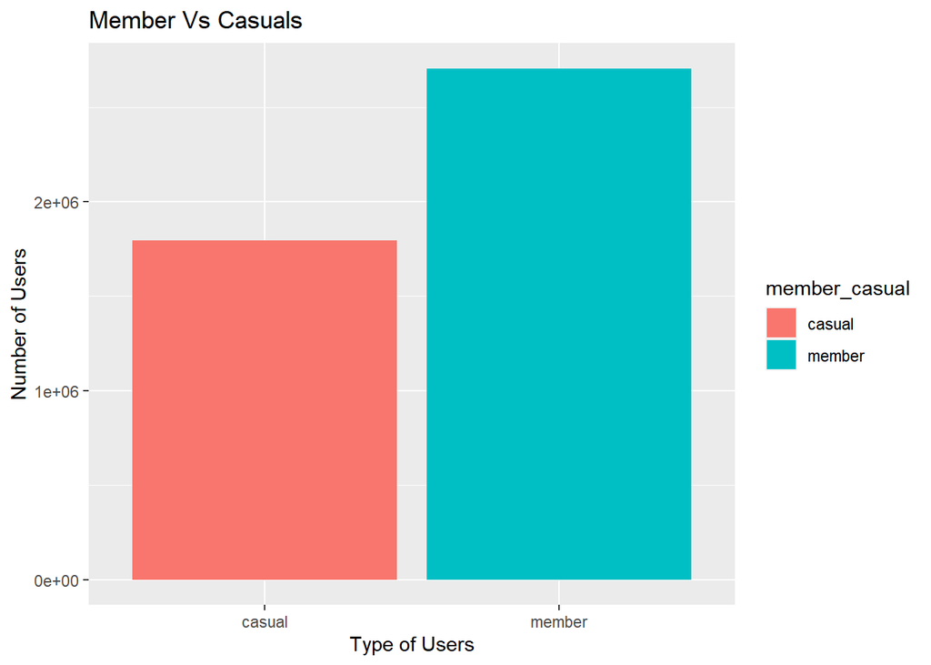

```r
ggplot(cyclistic_clean_data) + geom_bar(aes(x=member_casual, fill=member_casual)) + labs(title = 'Member Vs Casuals', x= "Type of Users", y= "Number of Users")
```

*As we can see that over 60% rides were taken by members, while others were casuals.

### Ride Duration Analysis

```r
cat('Average duration of Ride is:', mean(cyclistic_clean_data$trip_duration), "mins")
```

```
## Average duration of Ride is: 16.87832 mins
```

```r
cat('Maximun duration of Ride is:',round(max(cyclistic_clean_data$trip_duration)/60/24), "days")
```

```
## Maximun duration of Ride is: 24 days
```

#### Ride Duration Comparison

```r
bar <- cyclistic_clean_data %>% group_by(member_casual) %>% summarise(avg_ride_duration = mean(trip_duration))
bar
```

```
## # A tibble: 2 × 2
##   member_casual avg_ride_duration
##   <chr>         <drtn>
## 1 casual        23.69528 mins
## 2 member        12.36023 mins
```

```
## Defaulting to continuous.
```

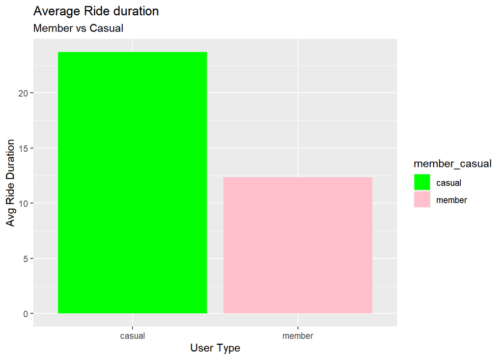

```r
ggplot(bar) + geom_col(aes(x=member_casual, y= avg_ride_duration, fill = member_casual)) + labs(title = 'Average Ride duration', subtitle = 'Member vs Casual', x='User Type', y='Avg Ride Duration') + scale_fill_manual(values = c('green','pink'))
```

*Average trip duration is around 16 mins.* By conducting further analysis we come to know that members in average take smaller trips(12mins) while casual customers take longer trips(23.5mins).

### Number Of Rides by Month

```r
cyclistic_clean_data %>% group_by(ride_month) %>% summarise(n=n()) %>% mutate(percent = n*100/sum(n)) %>% arrange(ride_month)
```

```
## # A tibble: 12 × 3
##    ride_month      n percent
##    <chr>       <int>   <dbl>
##  1 April      272560    6.06
##  2 August     605325   13.5
##  3 December   135403    3.01
##  4 February   149560    3.33
##  5 January    148284    3.30
##  6 July       642680   14.3
##  7 June       620350   13.8
##  8 March      215983    4.80
##  9 May        502545   11.2
## 10 November   255794    5.69
## 11 October    414269    9.21
## 12 September  535145   11.9
```

Note: Months are not in chronological order. *Rides in winter decrease to its lowest levels and rise is seen with arrival of spring and summer sees peak userage.

### Number Of Rides by Weekday

```r
cyclistic_clean_data %>% group_by(ride_day) %>% summarise(n=n()) %>% mutate(percent = n*100/sum(n))
```

```
## # A tibble: 7 × 3
##   ride_day      n percent
##   <ord>     <int>   <dbl>
## 1 Sun      619376    13.8
## 2 Mon      602674    13.4
## 3 Tue      637114    14.2
## 4 Wed      635657    14.1
## 5 Thu      661046    14.7
## 6 Fri      623140    13.9
## 7 Sat      718891    16.0
```

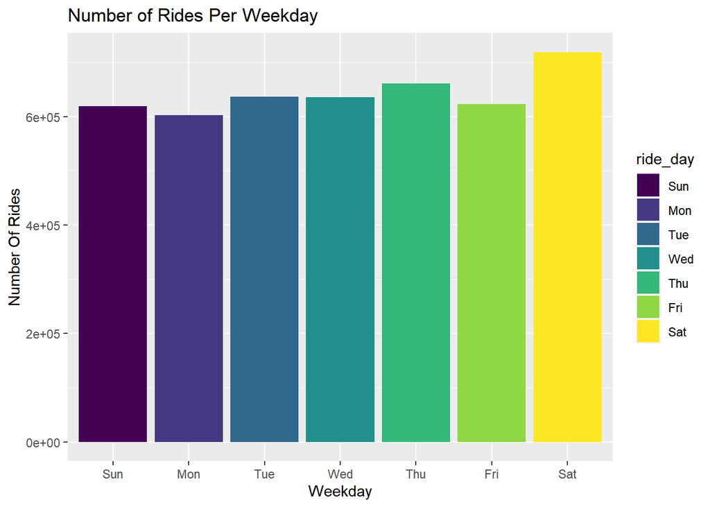

```r
ggplot(cyclistic_clean_data) + geom_bar(aes(x=ride_day, fill= ride_day)) + labs(title = 'Number of Rides Per Weekday', x='Weekday', y='Number Of Rides')
```

*Rides remain steady through out week, an increase is observed on Saturday(due to weekend).

#### Comparing Members And Casuals With Respect to Weekday rides

##### Members

```r
cyclistic_clean_data %>% group_by(ride_day) %>%  filter(member_casual=='member') %>% summarise(n=n()) %>% mutate(percent = n*100/sum(n))
```

```
## # A tibble: 7 × 3
##   ride_day      n percent
##   <ord>     <int>   <dbl>
## 1 Sun      310128    11.5
## 2 Mon      387373    14.3
## 3 Tue      434009    16.0
## 4 Wed      427603    15.8
## 5 Thu      427668    15.8
## 6 Fri      371171    13.7
## 7 Sat      347109    12.8
```

##### Casuals

```r
cyclistic_clean_data %>% group_by(ride_day) %>%  filter(member_casual=='casual') %>% summarise(n=n()) %>% mutate(percent = n*100/sum(n))
```

```
## # A tibble: 7 × 3
##   ride_day      n percent
##   <ord>     <int>   <dbl>
## 1 Sun      309248    17.2
## 2 Mon      215301    12.0
## 3 Tue      203105    11.3
## 4 Wed      208054    11.6
## 5 Thu      233378    13.0
## 6 Fri      251969    14.1
## 7 Sat      371782    20.7
```

##### Plot

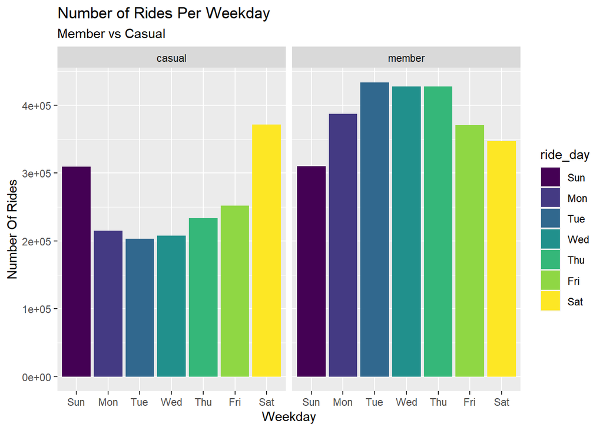

```r
ggplot(cyclistic_clean_data) + geom_bar(aes(x=ride_day, fill= ride_day)) + labs(title = 'Number of Rides Per Weekday',subtitle = 'Member vs Casual', x='Weekday', y='Number Of Rides') + facet_wrap(~member_casual)
```

*Members take most of the rides on office days, usage is down on weekend.* Casual customers usage is spiked on weekends and on office days it remain steady.

#### Type of Bikes

```r
cyclistic_clean_data %>% group_by(rideable_type) %>% summarise(n=n()) %>% mutate(percent =n*100/sum(n))
```

```
## # A tibble: 3 × 3
##   rideable_type       n percent
##   <chr>           <int>   <dbl>
## 1 classic_bike  2663394   59.2
## 2 docked_bike    176404    3.92
## 3 electric_bike 1658100   36.9
```

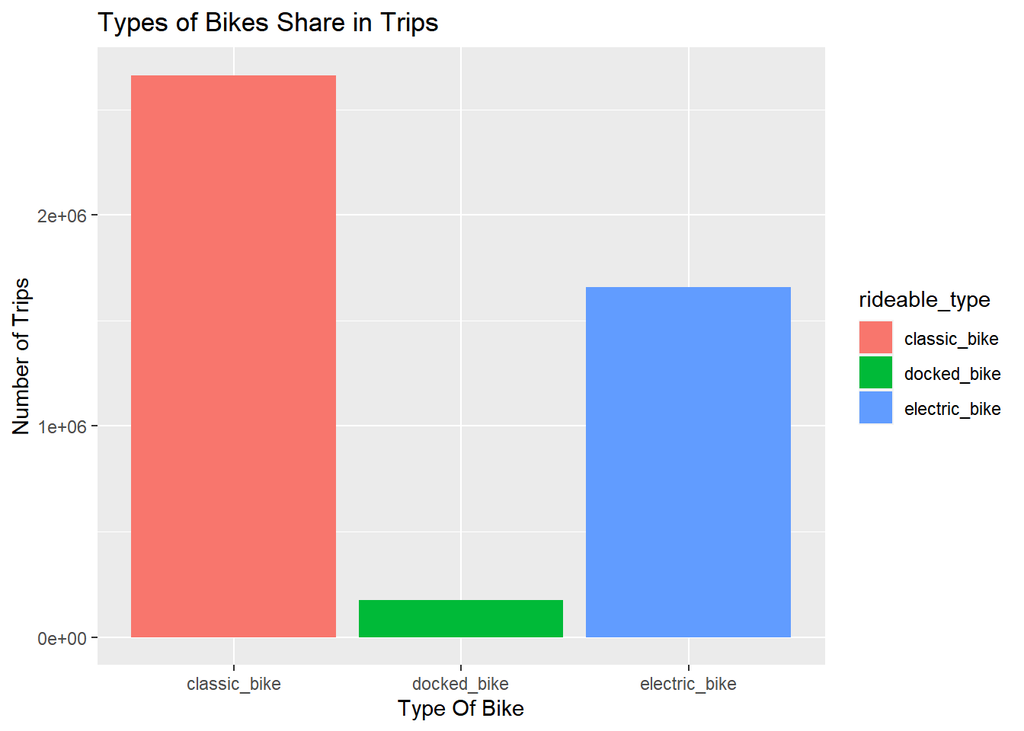

```r
ggplot(cyclistic_clean_data) + geom_bar(aes(x=rideable_type, fill = rideable_type)) + labs(title = 'Types of Bikes Share in Trips', x='Type Of Bike', y= "Number of Trips")
```

##### Ride type (Member vs Casual)

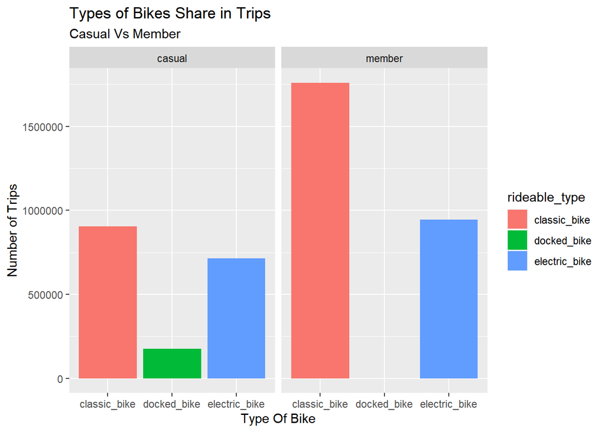

```r
ggplot(cyclistic_clean_data) + geom_bar(aes(x=rideable_type, fill = rideable_type)) + labs(title = 'Types of Bikes Share in Trips',subtitle = 'Casual Vs Member', x='Type Of Bike', y= "Number of Trips") + facet_wrap(~member_casual)
```

*Trends are almost same in respective categories of customers while market share do change. Docked bikes are not used by members at all.

*For Further Analysis and visualization we will continue in Tableau*

#### Montly Ridership And Avg Trip Duration

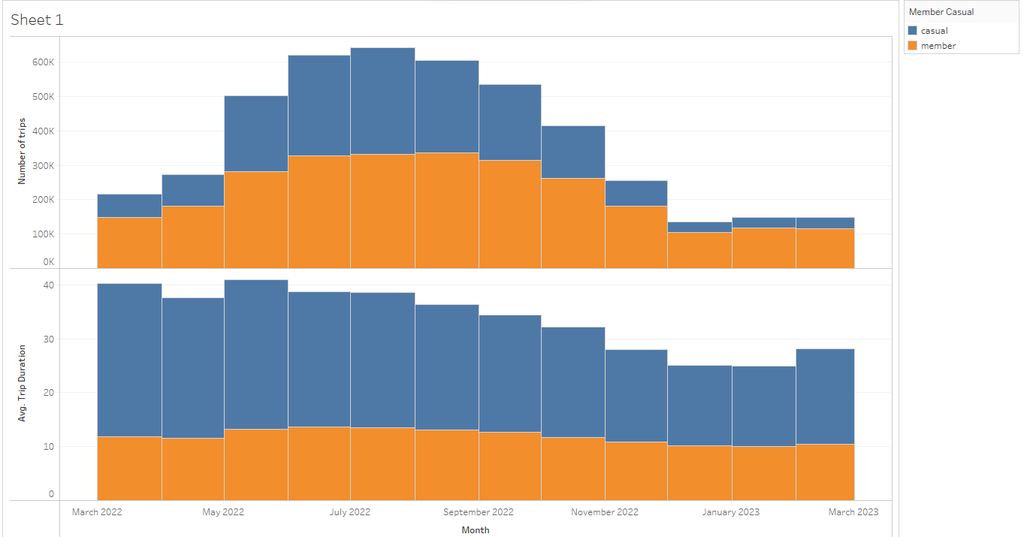

Data from march 2022 to feb 2023

- As discussed above ridership is at peak in summer and decreases in winter

#### Weekday data

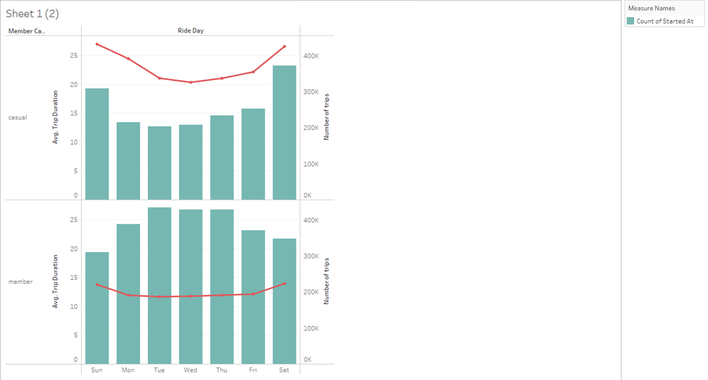

Above Data Split by Customer type and in weekday

- It can be clearly seem Average trip duration of casual riders is more than members.
- Casual riders usually tend to travel on weekends especially saturday while members mostly travel on workdays which means that they are formal workers.

#### Daily Ridership and TripDuration Data

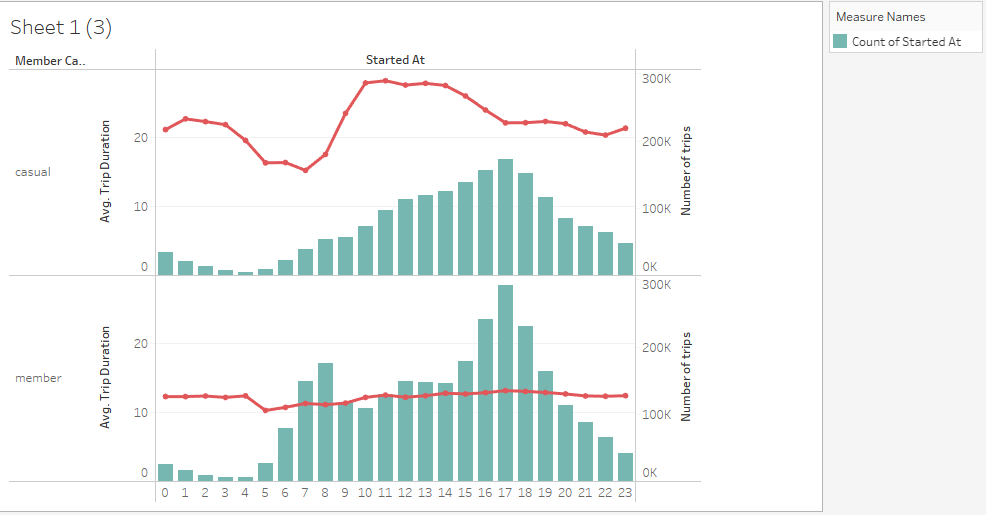

Ridership and Trip duration Data with Respect to Hours

- Most of the casual riders ride after noon until night.

### Stations Data (Top 10)

#### Start Station & End station

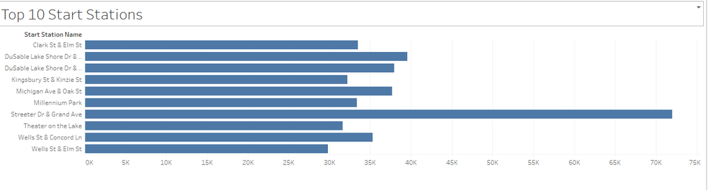

start station data

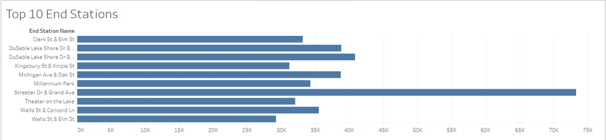

end station Data

- Top Start and End stations are almost same.

#### Start Station and End Station By Customer type

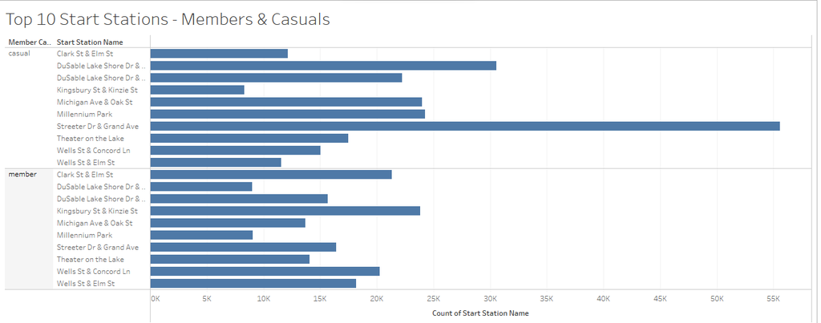

Start Station- Member&Casual

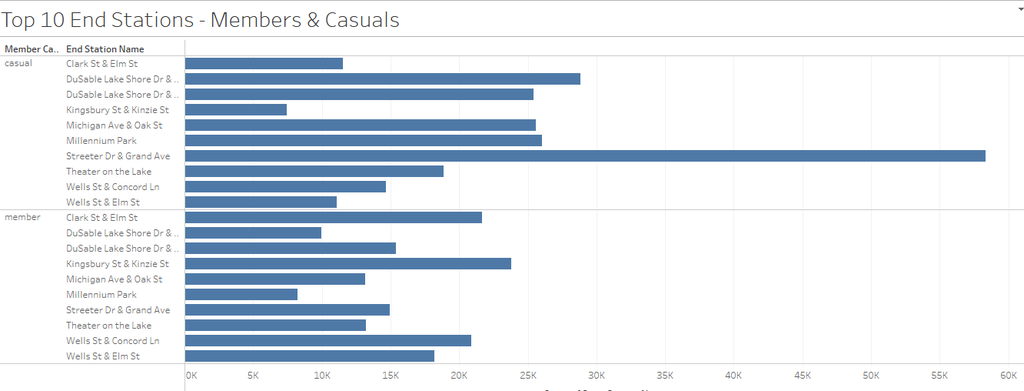

End Station- Member&Casual

- Streeter Dr & Grand Avenue is mos popular station due to large number of casual users starting and ending rides at this station

### Recommendations

1- Provide bikes to casual users on Weekend on a premium and offer membership at a discounted price.

2- Begin advertisement campaign on top 5 popular stations for casuals on weekend especially Saturday.

3- Begin this campaign at start of summer when user base is large.

Note: Above data visualizations can be seen at following link https://public.tableau.com/views/Google-capstonecyclist/Sheet1?:language=en-US&:display_count=n&:origin=viz_share_link